# 没人和我抢碗刷了——怀念姥姥

曲政

2007-11-07

那天我把照片传到相册里来，就是想为姥姥写一些文字，可是一直没有动。上周六，在同学寝室刷碗，我才意识到，下次回家，就不会再有人和我抢碗刷了。

我从小是姥姥带大的。虽然爷爷常住我家，可是我还是总往姥姥家跑。 那段路一趟十五分钟，赶上周末无聊，我带着表弟，去了又回，一天能走好几遍。在第三代六个孩子中，我虽然是外孙，但是感觉姥姥最疼我。大概是因为我常在她们眼前晃荡，油水和皮鞭都沾得多些吧。

小时候我的第一大爱好就是翻东西，姥姥家的几乎所有东西，我都了如指掌。她那里好玩的小东西也真多：尺子，扇子，顶环，钢条，钳子，锤子，盒子……那简直是一个羞涩的孩子的大观园了。现在想想，当年姥姥对我的宽容也真够大度的，东西有时找不到，很久找不到，也不骂我。直到后来，我突然有一天，发病似的，觉得干净整洁比随意乱放要好，从此改了性，她们才不用和我玩找宝的游戏。

其实，姥爷姥姥提防着了我这个翻东西的小贼，真正的好东西，他们早就藏好了。

姥爷爱做些小东西，现在叫做 DIY，比如用铁丝把铝管勒出缩口作烟嘴，这样的事我也爱帮忙。一天他叫我搭手搬东西，不经意间，就从我常翻的柜子底下，掏出一个绿色的小盒子，盖子带搭扣，背板有缝能穿在皮带上。姥爷说给你玩吧，那是你在地质队二姨出野外时发的。我打开来看，原来是个指南针（[地质罗盘](https://mp.weixin.qq.com/s?src=11&timestamp=1576239700&ver=2032&signature=cWqJgHhM8opixzifZp9ZrtHG2p7QXGeTgPv3YxRahz1UZ2n0-KQSWBnXlzL4DmhTj1cPBrQahm-7lryhUVCL-VljLKYJ54l-wWtD5g2UA1BlFOKvl-fxXX5DCWKoFaRC&new=1)）。它在我手里三四年，我也没搞懂它的小镜子和刻着线的指针盘，到底怎么配合，才能做出可靠的地质测量。姥爷到我懂事，才给我那个代表着二姨青春岁月的指南针。

今年春节，姥姥不知从哪里弄个小铁盒子，虽然很旧，但从转销和卡突看做工是还很扎实的。上面写的都是外文，里面放的东西，竟然是姥爷当年抗美援朝时得的几枚奖章。姥姥说，让我看看能不能把这铜片卖几个钱。姥姥在几次搬家之后，竟然还守护着姥爷的光荣。直到她预感到了什么，才拿出来，传给我们。

姥姥很坚强，当然也可以说心大。十年前姥爷车祸骨折，几次住院开刀，姥姥陪护他时，自己突发心肌梗塞，就进过了高危监护病房。姥姥自己做饭，单过了许多年，之后又经流离，姥姥仍然精神健旺，能吃能睡，天天下楼打牌。她的冷幽默，连我这西皮都佩服得五体投地。

高二暑假，我几乎天天去她那儿。就要升高三了，怎么那么闲？因为当年企图以自己的行动抵制补课，可是又抵制不住懒惰和诱惑，我就去姥姥家自习。当然，是她给我做饭吃。好像就是从那时，我才留意到姥姥的刷碗技术，尤其是对盘底的油的处理办法。首先，如果盘底残留很多油，又赶上吃的是从早市买来的馒头，那我就得负责地用馒头把油沾着吃掉。要是我实在不合作，她也没法。但从不是倒在厕所里，而是用很草的手纸先把盘底油吸起来。这招很管用，纸多是亲油的，手纸摸过的盘子，真的很省洗洁精。同时，又不怕脏了便池不好刷。别看姥姥一千度的近视镜，没读过书，也不认识字，但是，这份生活的原则和智慧，我们这一代有几个人能比得上呢。

后来，我妈和姥姥住到了一起。当然，我们的组合就成为一个老太，一个熟妇，加一个在外读书的小伙儿。旧楼拆迁后，姥姥乞宿于儿女家。04年春节，我和她俩住在老年公寓，过着饭来张口、衣来伸手的日子，晚上同赏《看了又看》，也颇怀念。搬回新家，她还没有住满三年。

四月二号，周一。早上手机奏乐，我以为是闹钟，其实，是丧钟。小姨问我要不要一起回去。我们做中午十二点半的飞机。小姨原来学校的同事在桃仙机场接，校长中途上车，一起到铁岭。见到妈妈，很镇定地组织着后事。她这么多年的磨练，坚强得像个超人。大姨说，白天还打了四圈麻将，晚上还去串门看了邻居，是夜里突然咳嗽难受，十二点多在家里咽的气，那时舅舅和大姨也到了，看着走的。

守了两天灵，周三出的殡，六号下午到浦东。我无聊地想，要是姥姥看到我的行程，没准儿会说我因为托她的福，上课期间，来了个“铁岭双飞五日游”。

姥姥高血压，不让吃糖，菜也得清淡。可是她又最喜欢吃早市的油炸糕，时时埋怨饭没味道。她一辈子忙碌独立惯了，近年来身体不好，干活儿容易累，就自己承担刷碗的工作。当然，我不同意妈妈同意她这样。我放假在家，就我刷，有时她和我抢。这就是题目的缘由。

现在，否极泰来，可是她却看不见了。她盼望努力了多年，让我爸妈复婚，现在他俩又(暂时)走到一起了。她可能觉得三闺女的孩子最有出息，可是我一进大学，就成了重修生，现在来上海交大，一样又拿奖学金了。几个儿女现在过节不再吵闹，而是主动的走在一起团聚了。

她没有看到么？不一定。我希望人真的有魂，我不怕这个鬼。因为，她永远是姥姥，我的姥姥。

我在家时，把关于她的照片拍下来一些留念。发在这里，是让有兴趣的人看看，养出的眼前这个朋友的，是怎样的一个老太太。

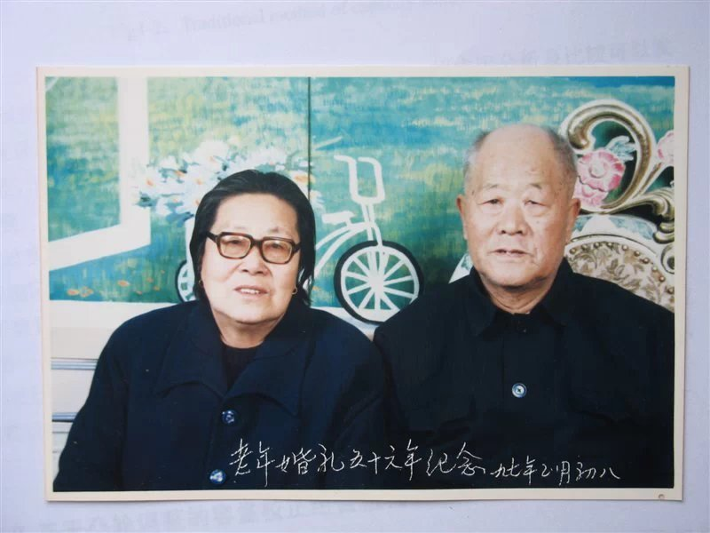

图1：我怎么记得是在市政府礼堂的生日宴

[figure not shown]

图2：我手里的魔方，直到我初中时还有。但是，它在我手里，只出现过一面全和六面全

[figure not shown]

图3：左起：二姨家的表哥，大我十个月。中间：舅舅家的表姐，大我四岁。右边，小时候的我，小我现在不知多少岁，可是比现在帅多了

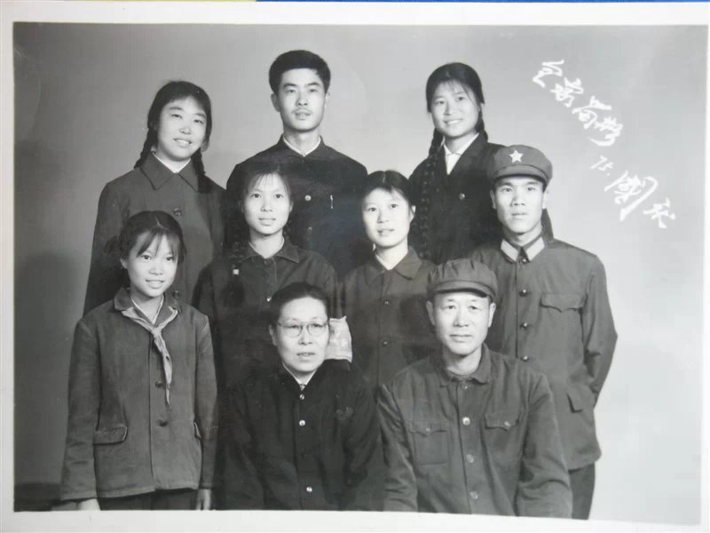

图4：文革中，我姥姥多瘦。称不上是全家福，有舅妈和大姨父，还没有二姨父，爸爸，老姨父。因为二姨的辫子还没剪，我妈还正傻，小姨还带红领巾

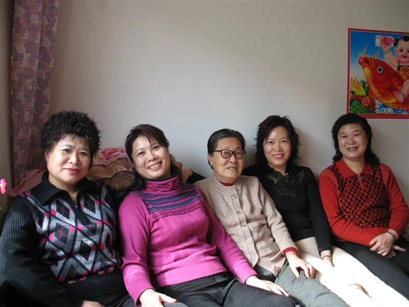

图5：今年春节，姥姥用恐吓的口吻，叫回了大连的二姨和上海的小姨。当时，有人提醒我说，老人的预感很准的，恐怕就是这一年的事了。赶巧有天早上她们做在一起，母女五人一并床，我觉得有趣，就抢拍了这张。没想到，就是最后的机会

2007-11-7 23:20 首发于 QQ 空间

1楼 评论时间: 2007-11-08 18:25:23

> 亲情是无法用语音来描述，是用我们的心去聆听去感受！谢谢你，提醒了我，一年来，因为太多太多的事情，忽略了我的宝贝姥姥和姥爷，喜欢他们睡在我身边的感觉和气息！总让他们为我担心，回到以前，经常的陪陪他们！

我

> 常去听听他们的唠叨，那里有真正的生活的智慧呀

2楼 评论时间: 2007-11-09 19:38:24

> 性情流露 真实感人 姨妈照顾 家庭幸福 bless！！

> > 刘大哥的诗做得好，将来我出文集时，一定加上，“有诗为证：……”

3楼 评论时间: 2007-11-09 21:59:52

祝老人在那边一切都好。

[我] 多谢小师傅

4楼 评论时间: 2007-11-10 10:54:32

让我好怀念以前的日子<sub>~</sub>

[我] 是呀，回不去了，只能怀念

5楼 评论时间: 2007-11-10 18:15:32

我想对你给我的留言说几句，当时我还在享受美食呢，可是看了以后的冲动，让我放下美食，不得不说几句。

你说：“什么是感情基础，想必就是两个人共同的经历吧”，这句话说得真好，让我感悟出你有刘墉一般的对感情的细腻体会。 关于思想的流露，你的笔法是涓涓细流般的，总能让人回味三日，那片留言让我很感动。

你对姥姥的怀念也是让读这篇文章的人和你共同分享了，这就是高明之处。 你对别人说废话的批判，也让我对你说的话抱着挑剔的眼光留意着，长时间的观察后发现，你的废话的确很少，就算有，也是偶尔被风吹起淡淡的沙尘，对空气质量的影响近乎为零，因为没有什么事情是绝对会如何如何的，像你做得这样好已经很优秀了。

总之呢，你这个朋友是个90%以上新好男人了，最值得感谢的是，你是一个不停地带给我智慧的朋友。

[我] 恩，又学一点：少批人，人也少批我，要批人，先自正身。 PS：别夸我，请注意，帮助我，低调点。

6楼 评论时间: 2007-11-12 08:24:00

还是我从常州走之前的事巴。 有一年？ 日子真快。 可是亲情是越积越厚。